# Analyze High-Resolution-Mass-Spectrum Data using R Package MALDIquant

install.packages(c(“MALDIquant”, “MALDIquantForeign”))

MALDIquant Package Demo http://strimmerlab.org/software/maldiquant/  
https://link.springer.com/chapter/10.1007/978-3-319-45809-0_6

Applicaition on FT-ICR data

## Load FT-ICR data and create MassSpectrum object

```r
# Read in FT-ICR data with two columns: m/z and intensity, PP12 is unlabelled control, PP13 is 13C fed sample
PP12 <- read.csv("pos_polar_C12_4uL_000001.csv", header=T)
PP13 <- read.csv("pos_polar_C13_4uL_000001.csv", header=T)
head(PP13)
```

```
##        m.z intensity
## 1 75.42216  155233.8
## 2 78.51272  159919.8
## 3 78.66075  204970.6
## 4 79.93759  156085.2
## 5 80.15422  140154.0
## 6 80.42467  155692.5
```

```r
# Create MassSpectrum object
library("MALDIquant")
```

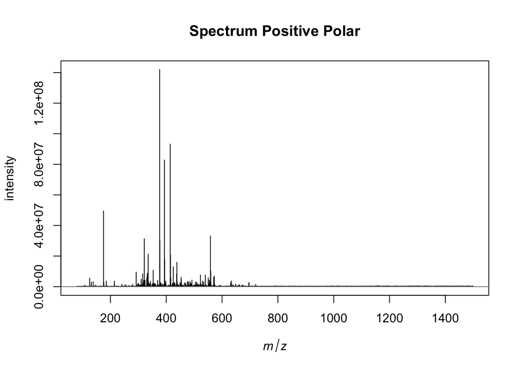

```r
s12 <- createMassSpectrum(mass=PP12$m.z,intensity=PP12$intensity,metaData=list(name="Spectrum Positive Polar"))
s13 <- createMassSpectrum(mass=PP13$m.z,intensity=PP13$intensity,metaData=list(name="Spectrum Positive Polar"))

## select a range
plot(s12)
```

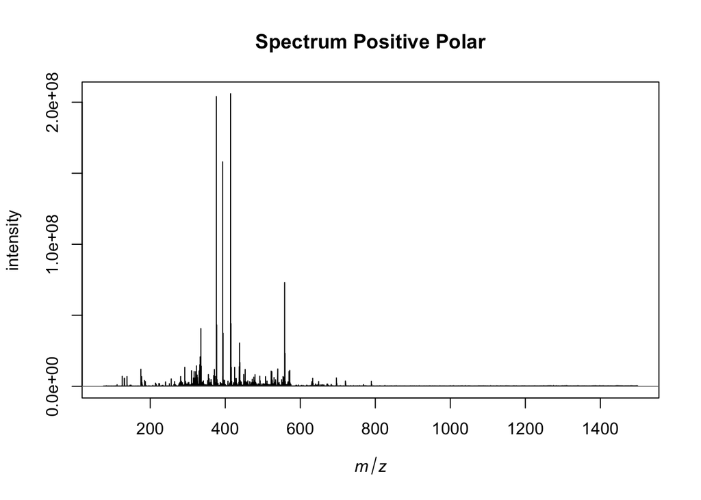

```r
plot(s13)
```

## Trim MassSpectrum object separately

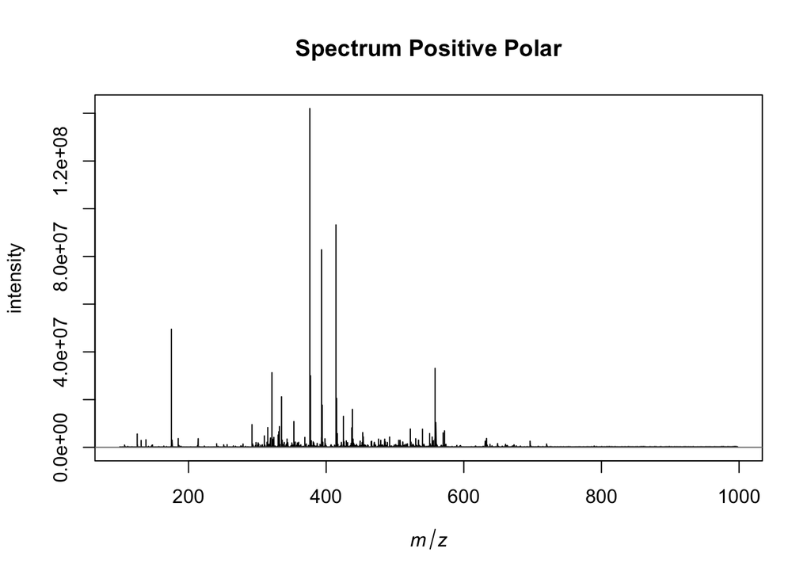

```r
#  trims an AbstractMassObject object. That is useful if some mass ranges should be excluded from further analysis.
## remove all mass lower 3000 and higher 8000
s12 <- trim(s12, range=c(100, 1000))
plot(s12)
```

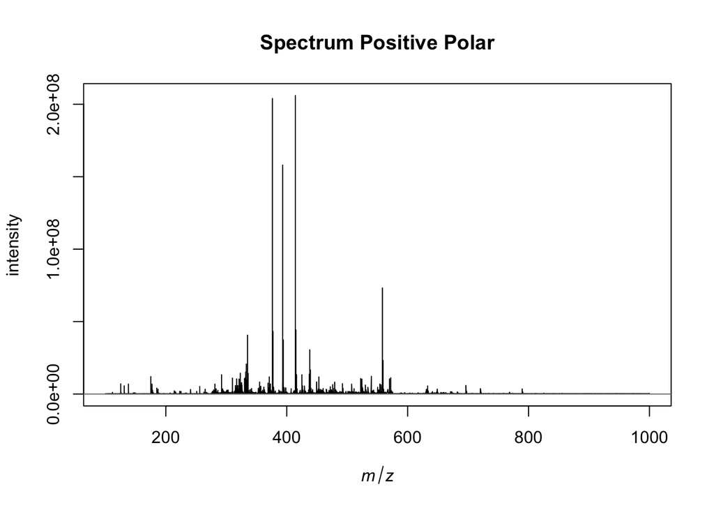

```r
s13 <- trim(s13, range=c(100, 1000))
plot(s13)
```

## Make a MassSpectrum list containing multiple MassSpectrum objects

```r
## create two MassSpectrum objects and add them to a list
slist <- list(s12, s13)
# ensure that all spectra cover the same m/z range.
# choose largest overlapping mass range for all spectra
trim(slist)
```

```
## [[1]]
## S4 class type            : MassSpectrum
## Number of m/z values     : 4231
## Range of m/z values      : 100.04 - 997.913
## Range of intensity values: 1.376e+05 - 1.42e+08
## Memory usage             : 67.359 KiB
## Name                     : Spectrum Positive Polar
##
## [[2]]
## S4 class type            : MassSpectrum
## Number of m/z values     : 4205
## Range of m/z values      : 100.013 - 997.362
## Range of intensity values: 1.396e+05 - 2.06e+08
## Memory usage             : 66.953 KiB
## Name                     : Spectrum Positive Polar
```

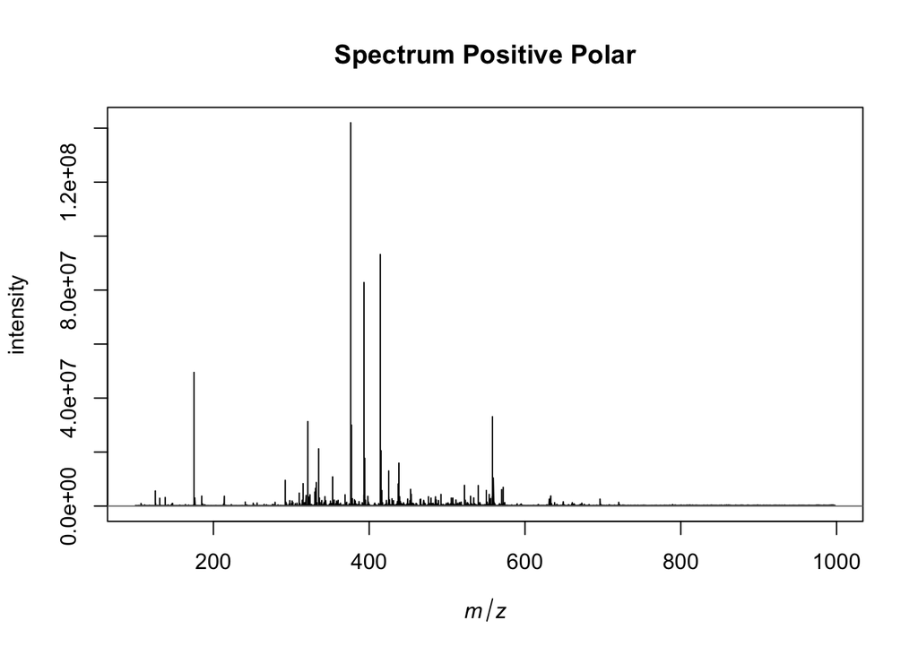

```r
plot(slist[[1]], sub="")
```

## Transformation and Smoothing

spectra <- smoothIntensity(spectra, method= “SavitzkyGolay”,halfWindowSize=20) (smoothing is not good)

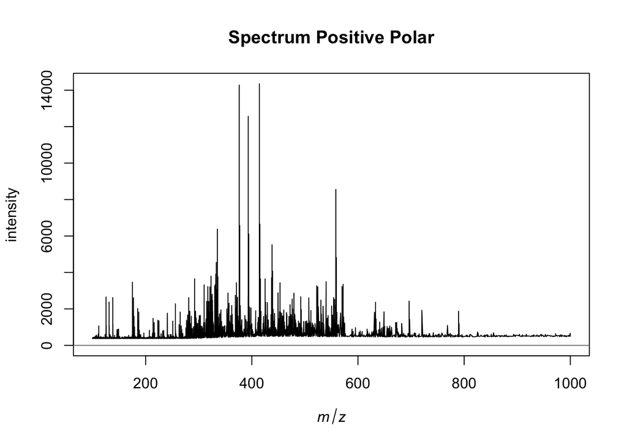

```r
spectra <- transformIntensity(slist, method="sqrt")
plot(spectra[[2]])
```

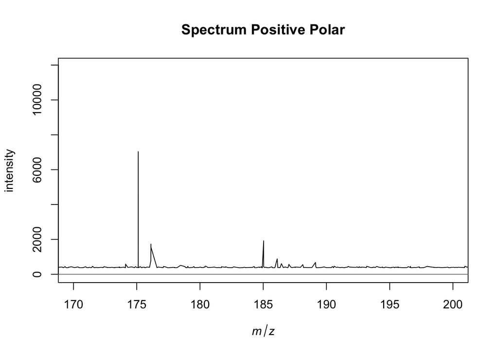

```r
plot(spectra[[1]], xlim=c(170, 200))
```

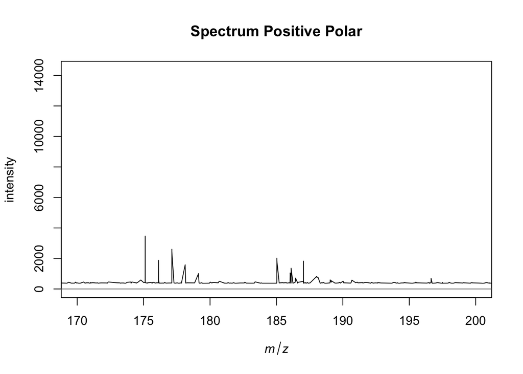

```r
plot(spectra[[2]], xlim=c(170, 200))
```

## Baseline Correction

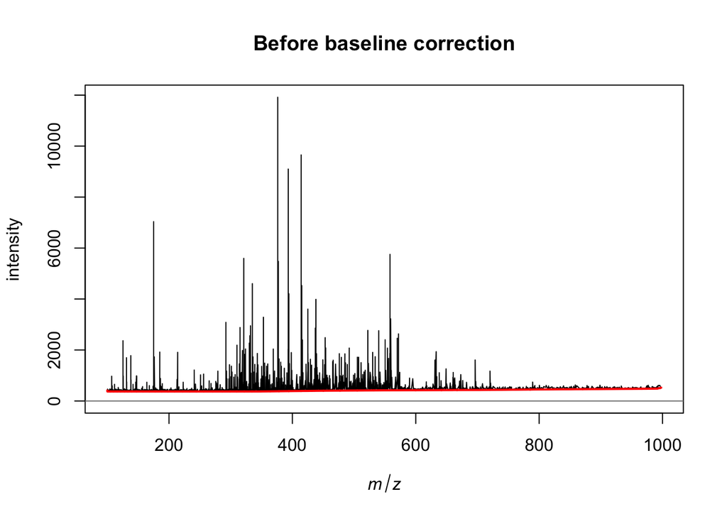

```r
baseline <- estimateBaseline(spectra[[1]], method="SNIP",iterations=150)
plot(spectra[[1]], sub="", main="Before baseline correction")
lines(baseline, col="red", lwd=2)
```

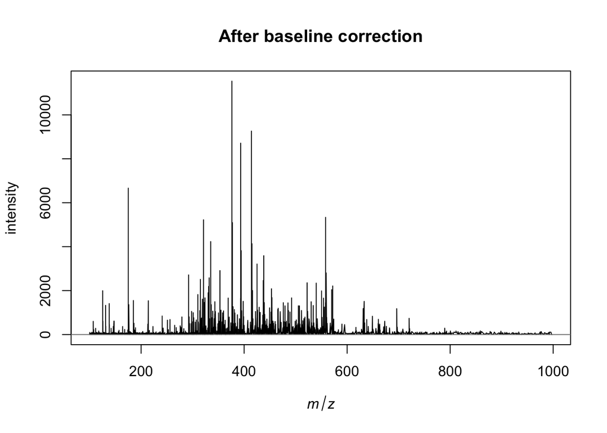

```r
# Substrate baseline
spectra <- removeBaseline(spectra, method="SNIP",
iterations=150)
plot(spectra[[1]], sub="", main="After baseline correction")
```

## Peak Detection and Computation of Intensity Matrix

Before we perform the peak detection algorithm we estimate the noise of the spectra to get a feeling for the signal-to-noise ratio.

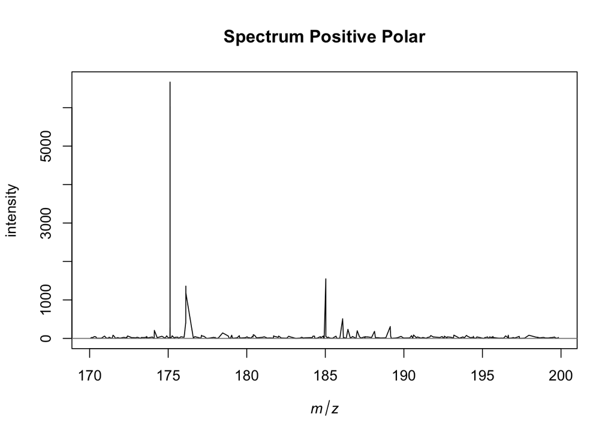

```r
spectratrim <- trim(spectra, range=c(170, 200))
plot(spectratrim[[1]])
```

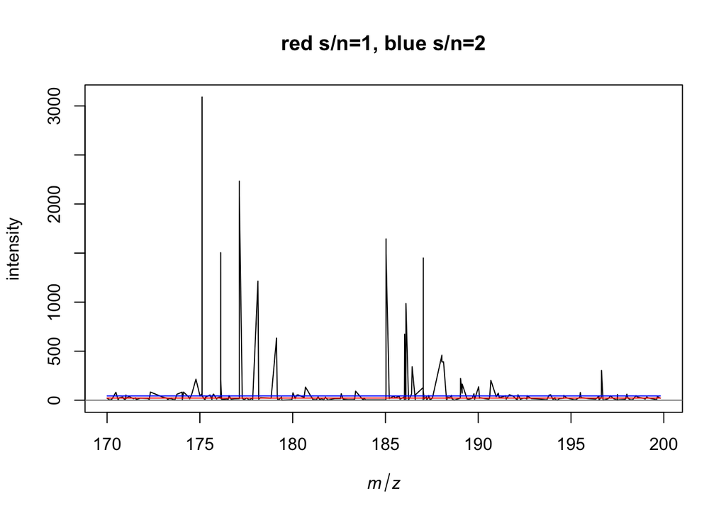

```r
noise <- estimateNoise(spectratrim[[2]])
plot(spectratrim[[2]], main="red s/n=1, blue s/n=2")
lines(noise, col="red")
lines(noise[, 1], 2*noise[, 2], col="blue")
```

Peak Detection

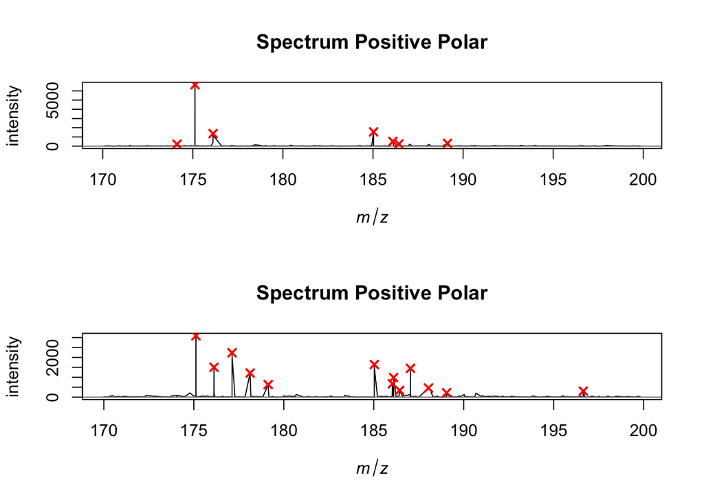

```r
# halfWindowSize change the number of peaks detected
peaks <- detectPeaks(spectratrim, halfWindowSize=2, SNR=10)
par(mfrow = c(2, 1))
plot(spectratrim[[1]])
points(peaks[[1]], col="red", pch=4, lwd = 2)
plot(spectratrim[[2]])
points(peaks[[2]], col="red", pch=4, lwd = 2)
```

Plot one peak to check it’s the same in two spectra

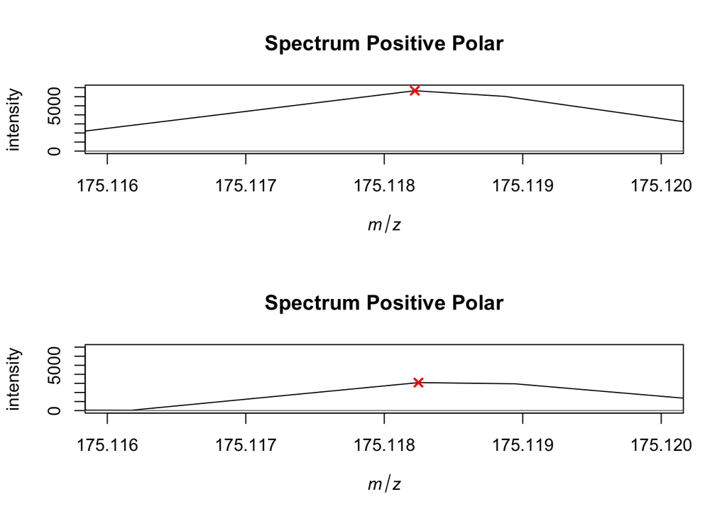

```r
par(mfrow = c(2, 1))
plot(spectratrim[[1]],xlim=c(175.116,175.120),ylim=c(0,7000))
points(peaks[[1]], col="red", pch=4, lwd = 2)
plot(spectratrim[[2]],xlim=c(175.116,175.120),ylim=c(0,7000))
points(peaks[[2]], col="red", pch=4, lwd = 2)
```

Notice that the peak positions are not exactly the same.

Make intensity matrix

```r
featureMatrix <- intensityMatrix(peaks, spectratrim)
featureMatrix
```

```
##      174.1181779 175.1182202 175.1182464 176.121543 176.1215979
## [1,]   208.48130    6664.578    6639.200   1359.382    1344.831
## [2,]    82.90837    3051.884    3090.453   1490.786    1504.362
##      177.1249068 178.1282421 179.1315803 185.0315411 185.0321716
## [1,]    66.33021    5.150436    3.510503    1539.387    1548.681
## [2,]  2234.09568 1214.116652  633.538214    1644.725    1511.640
##      186.0348708 186.1034624 186.1037156 186.4380477 186.4381758
## [1,]    318.7863    511.7276    509.0521    236.2064    236.0136
## [2,]    673.3529    802.5454    985.4912    339.4151    340.6411
##      187.0389526 188.0415084 189.0456986 189.1338015 196.642708
## [1,]    188.3354    107.5300    217.0119   308.14420    82.7315
## [2,]   1449.5985    458.9334    221.9664    91.47205   304.0034
## attr(,"mass")
##  [1] 174.1182 175.1182 175.1182 176.1215 176.1216 177.1249 178.1282
##  [8] 179.1316 185.0315 185.0322 186.0349 186.1035 186.1037 186.4380
## [15] 186.4382 187.0390 188.0415 189.0457 189.1338 196.6427
```

Notice that the peak positions (mass) are very similar but not numerically identical. There are multiple similar m/z. Binning is required to achieve identity:

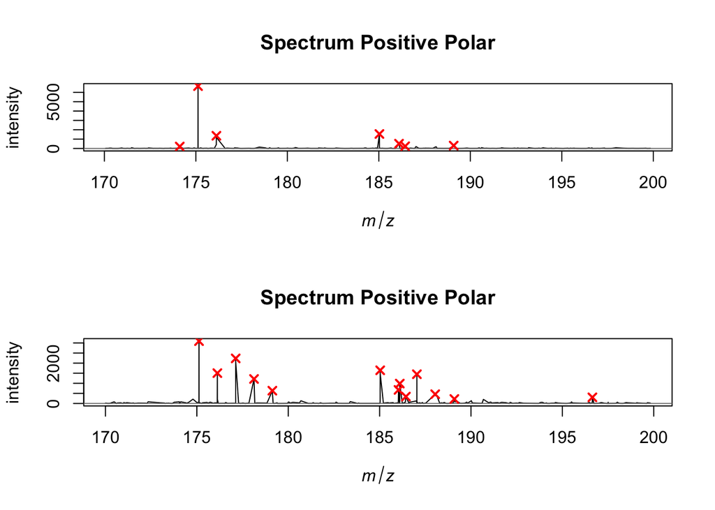

```r
# The binning is needed to make similar peak mass values identical.
peaks <- binPeaks(peaks, tolerance=0.002)
par(mfrow = c(2, 1))
plot(spectratrim[[1]])
points(peaks[[1]], col="red", pch=4, lwd = 2)
plot(spectratrim[[2]])
points(peaks[[2]], col="red", pch=4, lwd = 2)
```

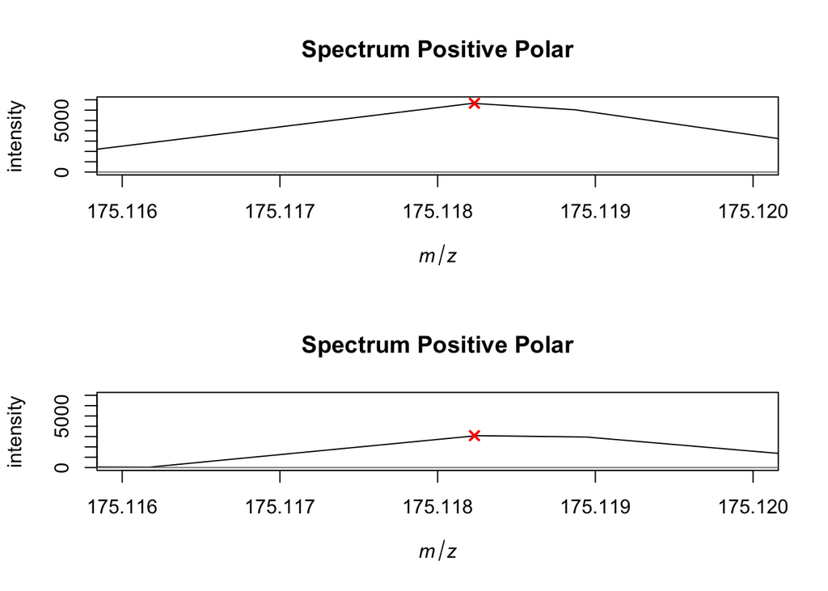

```r
par(mfrow = c(2, 1))
plot(spectratrim[[1]],xlim=c(175.116,175.120),ylim=c(0,7000))
points(peaks[[1]], col="red", pch=4, lwd = 2)
plot(spectratrim[[2]],xlim=c(175.116,175.120),ylim=c(0,7000))
points(peaks[[2]], col="red", pch=4, lwd = 2)
```

```r
featureMatrix <- intensityMatrix(peaks, spectratrim)
featureMatrix
```

```
##      174.1181779 175.1182333 176.12157045 177.1249068 178.1282421
## [1,]   208.48130    6664.578     1359.382    66.33021    5.150436
## [2,]    82.90837    3090.453     1504.362  2234.09568 1214.116652
##      179.1315803 185.03185635 186.0348708 186.103589 186.43811175
## [1,]    3.510503     1548.681    318.7863   511.7276     236.2064
## [2,]  633.538214     1644.725    673.3529   985.4912     340.6411
##      187.0389526 188.0415084 189.08975005 196.642708
## [1,]    188.3354    107.5300     308.1442    82.7315
## [2,]   1449.5985    458.9334     221.9664   304.0034
## attr(,"mass")
##  [1] 174.1182 175.1182 176.1216 177.1249 178.1282 179.1316 185.0319
##  [8] 186.0349 186.1036 186.4381 187.0390 188.0415 189.0898 196.6427
```